# Parameter estimation

Once we know how to solve an ODE with known parameters, the next step is to infer the model directly from the data.

### Setting up

Let’s load the necessary libraries:

```r
library(dplyr)
library(ggplot2)
library(knitr)
library(deSolve)
library(bbmle)
```

The first step is to recreate the function to perform the ODE solving.

```r
sir_fun <- function(beta, gamma, S0, I0 = 1 - S0, R0 = 0, times, N = 1) {

  # the differential equations:
  sir_equations <- function(time, variables, parameters) {
    with(as.list(c(variables, parameters)), {
      dS <- -beta * I * S
      dI <-  beta * I * S - gamma * I
      dR <-  gamma * I
      return(list(c(dS, dI, dR)))
    })
  }

  # the parameters values:
  parameters_values <- c(beta  = beta, gamma = gamma)

  # the initial values of variables:
  initial_values <- c(S = S0, I = I0, R = R0)

  # solving
  out <- ode(initial_values, times, sir_equations, parameters_values)

  # returning the output:
  as.data.frame(out) %>%
    mutate(across(-time, ~ .x * N)) # Scale to population
}
```

### Data simulation

To simulate the data we generate an epidemic with known parameters plus some noise. The R_0 in this situation is 2.

```r
N = 1000

set.seed(1270129109) # for reproducibility

# Theoretical trajectory given beta and gamma parameters
sir_data_theor <- sir_fun(0.5, .25, S0 = .999, times = seq(0, 100)) %>%
  transmute(day = time, cases = I * N)

# Observed data after adding noise
sir_data_obs <- mutate(sir_data_theor, cases = rnbinom(n(), mu = cases, size = 20))

# Forcing the introduction of 1 case in the population
sir_data_obs$cases[1] <- 1
```

Let’s see how does it look:

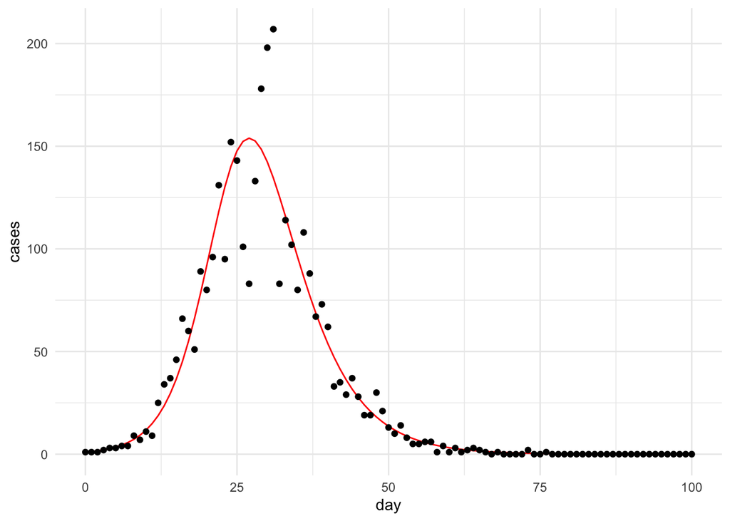

```r
ggplot() +
  geom_line(data = sir_data_theor, mapping = aes(day, cases), color = 'red') +
  geom_point(data = sir_data_obs, mapping = aes(day, cases)) +
  theme_minimal()
```

Next, we need to define a “Likelihood function” or “Score function” or “Objective function”, which estimates the outbreak curve for each combination of beta and gamma parameters and evaluates how well it fits the data.

```r
LLpois <- function(beta, gamma, day, cases, N) {
  # the optimizer works with values from -Inf:+Inf but SIR parameters can only
  # be positive (R+)
  beta <- exp(beta)
  gamma <- exp(gamma)

  I0 <- cases[1] # initial number of infectious
  observations <- cases[-1] # the fit is done on the other data points

  # generate one outbreak curve given the parameters
  predictions <- sir_fun(beta = beta, gamma = gamma,
                         S0 = 1 - I0/N, I0 = I0/N, R0 = 0, times = day, N)
  predictions <- predictions$I[-1] # removing the first point too

  if (any(predictions < 0)) return(NA) # removing impossible estimates

  # returning minus log-likelihood. Sum of logs is easier to manage than the
  # product of raw likelihoods
  -sum(dpois(x = observations, lambda = predictions, log = TRUE))
}
```

Using an “Optimizer” we are able to find the best set of parameters for the objective function that better describe the data:

```r
starting_param_val <- list(beta = 0.3, gamma = 0.3) # some starting parameters

estimates <- mle2(
  minuslogl = LLpois, # the objective function to optimize
  start = lapply(starting_param_val, log), # starting values on log scale
  fixed = list(N = 1000), # the population size is considered fixed
  method = "Nelder-Mead", # an optimization algorithm
  data = sir_data_obs # the simulated data
)
```

Which gives us the following estimated parameters:

```r
# the parameters were still on log scale.
# The third parameter is N which is fixed.
best_params <- exp(coef(estimates))[1:2]

print(best_params)
```

```
##      beta     gamma
## 0.4993768 0.2513257
```

with an R_0 of:

```r
print(as.vector(best_params['beta'] / best_params['gamma']))
```

```
## [1] 1.986971
```

Let’s see now how these parameters compare with the original data and the theorerical outbreak curve:

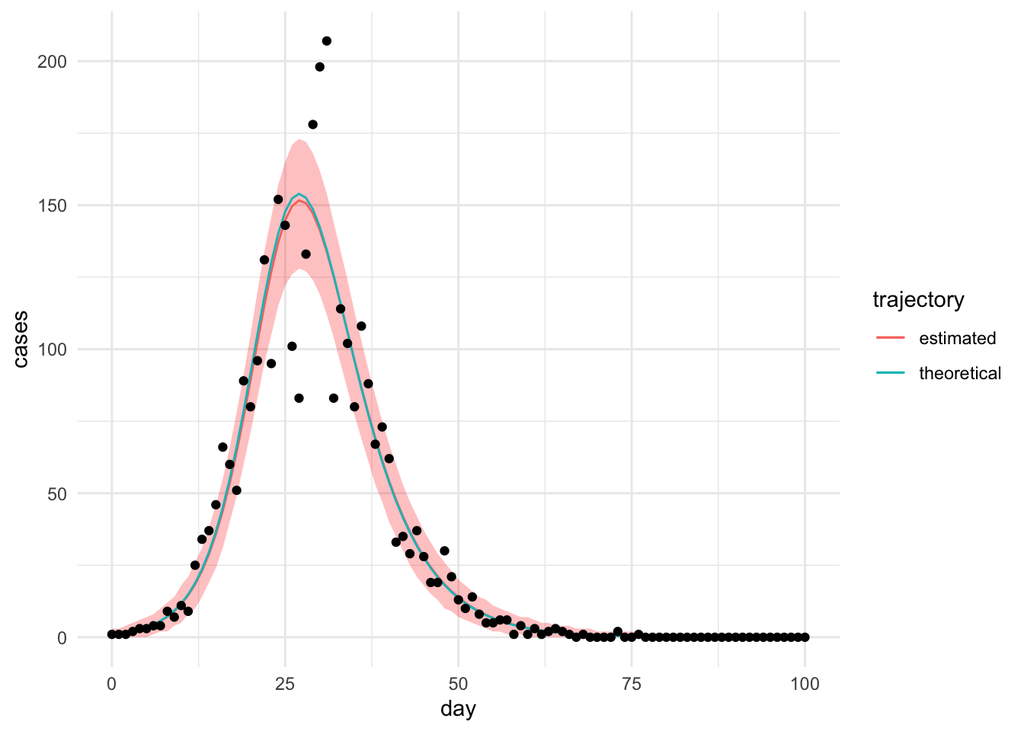

```r
# Generate the outbreak trajectory given the estimated parameters
best_predictions <- sir_fun(best_params["beta"],
                            best_params["gamma"],
                            S0 = 1 - sir_data_obs$cases[1]/N,
                            times = with(sir_data_obs, min(day):max(day)),
                            N = N)

ggplot(best_predictions, aes(x = time)) +
  # use a Poisson distribution to estimate the expected range of observed cases
  # at 95% probability
  geom_ribbon(aes(
    ymin = qpois(0.025, I),
    ymax = qpois(0.955, I)), fill = 'red', alpha = .25) +
  # plot the estimated trajectory
  geom_line(aes(y = I, color = 'estimated')) +

  # plot the theoretical trajectory
  geom_line(
    data = sir_data_theor,
    mapping = aes(day, cases, color = 'theoretical')) +

  # plot the observed data
  geom_point(data = sir_data_obs, mapping = aes(day, cases)) +
  theme_minimal() +
  labs(x = 'day', y = 'cases', color = 'trajectory')
```